# Stock Price Prediction XGBOOST Model

# Data Visualization

To better understand our dataset I will be creating visual representation of the data at hand.

Firstly I would like to know how time of day affects stock prices. In theory stocks have the most volatility on stock market opening hours diminishing throughout the first 3 hours and then picking up once again 1 hour before closing.

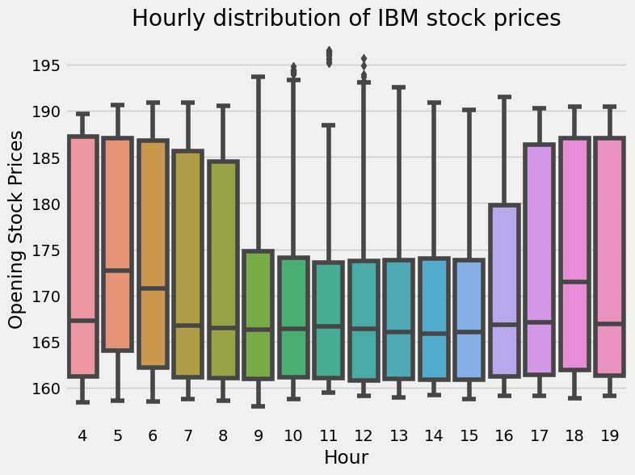

```python
fig,ax=plt.subplots(figsize=(8,6))
sns.boxplot(data=df,x='hour',y='1. open')
ax.set_xlabel("Hour")
ax.set_ylabel("Opening Stock Prices")
ax.set_title('Hourly distribution of IBM stock prices')
```

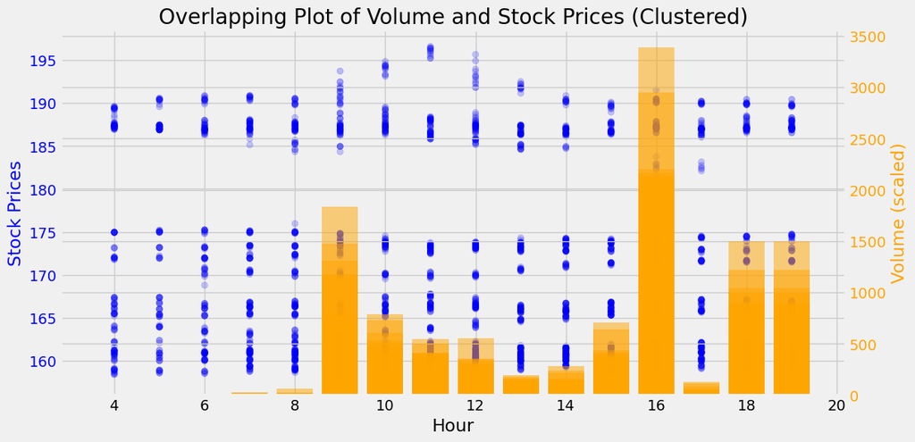

```python
fig, ax1 = plt.subplots(figsize=(12, 6))

# Calculate alpha (transparency) based on the volume
alpha_values = np.clip(df['5. volume'] / df['5. volume'].max(), 0.2, 1.0)  # Adjust the range as needed

# Scatter plot for stock prices on the left y-axis with adjusted transparency
ax1.scatter(df['hour'], df['1. open'], label='Stock Prices', color='blue', marker='o', alpha=alpha_values)
ax1.set_xlabel('Hour')
ax1.set_ylabel('Stock Prices', color='blue')
ax1.tick_params('y', colors='blue')

# Creating a secondary y-axis for volume on the right side
ax2 = ax1.twinx()
ax2.bar(df['hour'], df['5. volume'] / 1000, alpha=0.5, label='Volume (scaled)', color='orange')
ax2.set_ylabel('Volume (scaled)', color='orange')
ax2.tick_params('y', colors='orange')

plt.title('Overlapping Plot of Volume and Stock Prices (Clustered)')
plt.show()
```

Looking at the graph, it shows that when stock prices go up, it doesn't always happen with high trading volume. However, when there is a lot of trading activity (high volume), the stock prices usually don't drop much and often stay on the higher side. Lets take a look at how volatile stock prices are based on the day of the week.

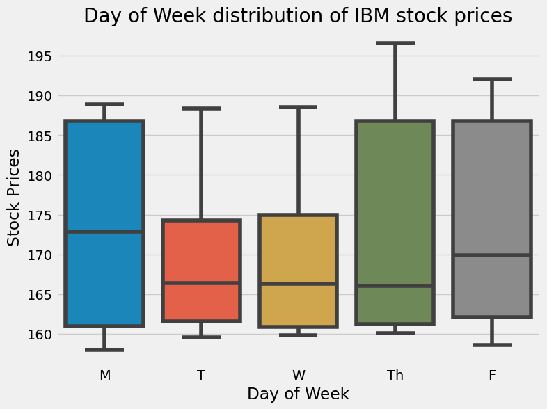

```python
fig,ax=plt.subplots(figsize=(8,6))
sns.boxplot(data=df,x='dayofweek',y='1. open')
ax.set_xlabel("Day of Week")
ax.set_ylabel("Stock Prices")
ax.set_xticklabels(['M', 'T', 'W', 'Th', 'F'])
ax.set_title('Day of Week distribution of IBM stock prices')
```

Monday: The stock tends to have a higher median price on Mondays compared to other days. This suggests that Mondays contribute to the perception that the stock is likely to either rise or maintain a high value. There is potential for further upward movement.

Tuesday - Wednesday: These days show lower volatility and maintain a lower median compared to other days. While Wednesdays have the potential for breakouts, caution is advised in investing, and it's essential to manage risks conservatively as breakouts may be reversed.

Lastly I am going to visualize price fluctuations within the time segment that I have chosen to better understand how the prices fluctuate during the month. This will allow us to identify and quarantine outliars from our data set as well as it helps us better understand stock movements.

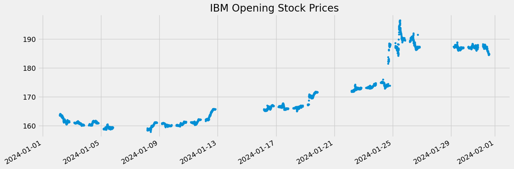

```python
df['1. open'].plot(style='.', figsize=(15,5),color=color_pal[0],title='IBM Opening Stock Prices')
```

# Building Model

```python
#Breaking our DataFrame into Target variable and contributing Feature Variables.
features = ["1. open","2. high","3. low", "4. close","5. volume",'hour','dayofweek']
variables = ['1. open Prediction']
```

```python
X = df.drop(columns=variables)
y = df[variables]
```

Here we are confirming that the shapes and values of our test and train sets are equal and have data.

```python
print(X)
print(y)
```

```
                     1. open  2. high   3. low  4. close  5. volume  hour  \
2024-01-31 14:15:00  184.710  184.823  184.522   184.522      16750    14
2024-01-31 14:10:00  184.800  184.970  184.700   184.775      16679    14
2024-01-31 14:05:00  184.920  184.975  184.650   184.810      25123    14
2024-01-31 14:00:00  184.970  185.150  184.660   184.900      27580    14
2024-01-31 13:55:00  185.013  185.075  184.910   184.945      13171    13
...                      ...      ...      ...       ...        ...   ...
2024-01-02 04:45:00  163.760  164.100  163.760   164.040        592     4
2024-01-02 04:20:00  163.950  163.950  163.650   163.950         16     4
2024-01-02 04:10:00  163.650  164.000  163.650   163.950         58     4
2024-01-02 04:05:00  163.650  164.090  163.650   164.090          3     4
2024-01-02 04:00:00  163.550  164.080  163.550   164.080         16     4

                     dayofweek
2024-01-31 14:15:00          2
2024-01-31 14:10:00          2
2024-01-31 14:05:00          2
2024-01-31 14:00:00          2
2024-01-31 13:55:00          2
...                        ...
2024-01-02 04:45:00          1
2024-01-02 04:20:00          1
2024-01-02 04:10:00          1
2024-01-02 04:05:00          1
2024-01-02 04:00:00          1

[3384 rows x 7 columns]
                     1. open Prediction
2024-01-31 14:15:00              184.50
2024-01-31 14:10:00              184.71
2024-01-31 14:05:00              184.80
2024-01-31 14:00:00              184.92
2024-01-31 13:55:00              184.97
...                                 ...
2024-01-02 04:45:00              164.09
2024-01-02 04:20:00              163.76
2024-01-02 04:10:00              163.95
2024-01-02 04:05:00              163.65
2024-01-02 04:00:00              163.65

[3384 rows x 1 columns]
```

```python
#Creating Test and Train data sets
X_train, X_test, y_train, y_test = train_test_split(X, y, test_size=0.3, random_state=42)
print(y_test)
```

```
                     1. open Prediction
2024-01-29 09:35:00             188.750
2024-01-29 16:20:00             186.520
2024-01-29 04:20:00             187.320
2024-01-24 16:40:00             182.510
2024-01-12 17:15:00             165.800
...                                 ...
2024-01-24 07:50:00             174.950
2024-01-30 10:30:00             187.540
2024-01-31 13:15:00             185.085
2024-01-02 14:00:00             161.178
2024-01-24 14:55:00             173.920

[1016 rows x 1 columns]
```

Now to save time from manually picking and choosing the best parameters for our model I am going to run GridSearch on the model to find the best combination of parameters, and to avoid the model from being over fitted I am implementing Early stopping rounds which means that when our model stops improving for 50 consequitive itterations it will stop.

```python
param_grid = {
    'n_estimators': [100, 200, 500, 1000],
    'learning_rate': [0.01, 0.1, 0.2],
    'max_depth': [3, 4, 5],
    'subsample': [0.8, 0.9, 1.0],
    'colsample_bytree': [0.8, 0.9, 1.0]
}

# Create an XGBRegressor instance
xgb_model = XGBRegressor()

# Set up early stopping to avoid overfitting
early_stopping_rounds = 50

# Create GridSearchCV instance
grid_search = GridSearchCV(
    xgb_model,
    param_grid=param_grid,
    scoring='neg_mean_squared_error',  # Use an appropriate scoring metric for regression
    cv=5,  # Use cross-validation with 5 folds
    n_jobs=-1,  # Use all available CPU cores
)

# Fit the grid search to our data
grid_search.fit(X_train, y_train)

# Print the best parameters found by the grid search
print("Best Parameters: ", grid_search.best_params_)
```

```
Best Parameters:  {'colsample_bytree': 0.8, 'learning_rate': 0.01, 'max_depth': 3, 'n_estimators': 500, 'subsample': 0.8}
```

```python
#Fitting our model with the best parameters.
xgb_model=grid_search.best_estimator_
xgb_model.fit(X_train, y_train, eval_set=[(X_train, y_train), (X_test, y_test)],
                early_stopping_rounds=early_stopping_rounds,
               verbose=True)
```

[output not shown]

```python
#Runing Feature importance to find out which of our features contribute the most to accuracy of our model.
pd.DataFrame(data=xgb_model.feature_importances_,
             index=xgb_model.feature_names_in_,
            columns = ['Importance'])
```

|  | Importance |
| --- | --- |
| 1. open | 0.243170 |
| 2. high | 0.506214 |
| 3. low | 0.055884 |
| 4. close | 0.192547 |
| 5. volume | 0.000672 |
| hour | 0.000592 |
| dayofweek | 0.000920 |

# Forecasting Stock Prices.

Firstly we need to run our model to see how accurate our predictions are, for that I will be running a prediction against our X test data.

```python
prediction_compare=y_test.copy()
prediction=bst.predict(X_test)
```

```python
#Putting Prediction and Opening Value side by side will allow us to better understand what is causing the error
#It is ideal to export this data into excel to take a closer look into the causes.
prediction_compare['Prediction']=prediction
prediction_compare.rename(columns={'1. open Prediction': 'Opening Value'}, inplace=True)
prediction_compare.sort_index(ascending=False)
```

|  | Opening Value | Prediction |
| --- | --- | --- |
| 2024-01-31 14:15:00 | 184.500 | 184.890152 |
| 2024-01-31 13:40:00 | 184.723 | 184.071426 |
| 2024-01-31 13:15:00 | 185.085 | 185.279678 |
| 2024-01-31 13:05:00 | 185.150 | 185.278656 |
| 2024-01-31 12:50:00 | 185.165 | 185.279678 |
| ... | ... | ... |
| 2024-01-02 06:05:00 | 163.500 | 164.020355 |
| 2024-01-02 05:30:00 | 163.930 | 164.020355 |
| 2024-01-02 05:15:00 | 164.000 | 164.032639 |
| 2024-01-02 04:45:00 | 164.090 | 164.020355 |
| 2024-01-02 04:05:00 | 163.650 | 164.020355 |

1016 rows × 2 columns

```python
#We need to find absolute variance between our predicted and actual data to make note of what days, hours, days of the week
#contribute the most to the highest variance drivers.
prediction_compare['variance'] = (prediction_compare['Prediction'] - prediction_compare['Opening Value']).abs()
sorted_predictions = prediction_compare.sort_values(by='variance',ascending=False)
#Saving the variance table to an excel spreadsheet for external analysis
sorted_predictions.to_csv('Outliars.csv',index=True)
sorted_predictions
```

|  | Opening Value | Prediction | variance |
| --- | --- | --- | --- |
| 2024-01-24 17:05:00 | 182.35 | 179.961899 | 2.388101 |
| 2024-01-24 18:30:00 | 188.29 | 185.976624 | 2.313376 |
| 2024-01-26 16:50:00 | 191.53 | 189.604294 | 1.925706 |
| 2024-01-25 08:05:00 | 185.34 | 186.824768 | 1.484768 |
| 2024-01-24 07:25:00 | 174.86 | 176.269211 | 1.409211 |
| ... | ... | ... | ... |
| 2024-01-03 15:10:00 | 160.45 | 160.450272 | 0.000272 |
| 2024-01-17 15:40:00 | 165.75 | 165.750244 | 0.000244 |
| 2024-01-30 14:20:00 | 186.98 | 186.979782 | 0.000218 |
| 2024-01-03 17:35:00 | 160.30 | 160.300049 | 0.000049 |
| 2024-01-18 13:10:00 | 166.02 | 166.019974 | 0.000026 |

1016 rows × 3 columns

After examining the factors contributing to significant fluctuations, I noticed a pattern. Specifically, days with high variance are often January 24th and 26th. January 24th falls on a Wednesday, and January 26th is a Friday. Fridays tend to be highly unpredictable and volatile. Additionally, these days are towards the end of the month, which might further raise the chances of unexpected outcomes. On the other hand, Wednesdays, as observed in the earlier graph, show reversals and fluctuations, making them less reliable for forecasting.

```python
#As a finishing touch I am running an accuracy test on my model.
from sklearn.metrics import mean_squared_error
mse = mean_squared_error(y_test['1. open Prediction'], prediction, multioutput='raw_values')
print(f"Mean Squared Error: {mse}")
```

```
Mean Squared Error: [0.04699772]
```

Mean Squared Error of 0 means that every single prediction is 100% on point, and our result of 0.047 means that the model is very accurate.

# Conclusion

From my research I have been able to identify multiple key stock price behaviours that contribute to the price. Although the model have already proved to be very accurate I believe that it can be adjusted and sliced to provide even better accuracy. Here are some ways it can be made better:

# Post and Pre market hours

XGBoost Model has been built on 5 minute time series data from 4 am to 7 pm. Majority of trading platforms (excluding platforms like Robinhood) do not allow for participants to trade outside of the established market hours 9 am to 4 pm. I believe that this has an effect of how the model prioriotizes certain features such as Volume, DayofWeek and etc. What I would like to do in the future is to break the existing dataset and model into three segments Pre market, Post market and Active market models because each of these segments should have its own unique behaviour. For example Pre market hours should see a lot more participants because at that time European markets are closing so they have an opportunity to invest internationally. While Post market hours for North America are at a time when most of Europe is asleep resulting in lower volume. Due to low volume, stock prices become a lot more volatile resulting in higher price jump as there is lower supply for the existing demand. Active market hours are a lot more dependent on volume, for example a well known concept of stock break out (occurs when a stock breaks out of its established price limits for example, stock that normally bounces off price levels 170,175,180 (usually in $5 increments) limit finally goes and stays above that value) happens when the stock volume is high. Knowing this in the future I could add an additional feature to my model classifying Pre/Post/Active market hours.

# Data Set

One of the biggest challenges when it comes to creating an accurate Machine Model is to have and be able to compute large enough data sets to capture all of potential outcomes. Idealy we would use 5 years of data adjusting the samples for outliars and extraordinary effects. Some of the main ones are: Seasonal Effect, Month effect(Feburary is a month that historically have always been a low volume, low activity month), Covid effect, Recession status, Short Trade Hours among others. This can all be done on a powerful machine in a real work setting, however for this project I will be using this model as a proof of concept rather than the finished product.

# Adding additional Features

In a real work setting I could add multiple additional features to the model to improve accuracy further. Some of the features would be: Feature Vector of n segments to have a trending prediction instead of a single feature prediction, short trade days, national holidays, public market speculation, and years.

# Final words

Overall this project has been a personal and professional success I believe that I have been able to successfuly analyze the stock itself as well as create a functional predictive model. It has shown very accurate predictions and it can only be restructured to be more efficient and accurate if worked on in work setting. I appreciate the reader of this report for giving it your valuable time and I would love to hear any ideas on how this can be made better!